# N741 Spring 2019 - Homework 6 - ANSWER KEY

Melinda Higgins

03/27/2019

## Homework 6

### Background and Information on HELP Dataset

For homework 6, you will be working with the **HELP** (Health Evaluation and Linkage to Primary Care) Dataset.

The HELP Dataset:

- You can learn more about the HELP (Health Evaluation and Linkage to Primary Care) dataset at https://nhorton.people.amherst.edu/sasr2/datasets.php. This dataset is also used by Ken Kleinman and Nicholas J. Horton for their book “SAS and R: Data Management, Statistical Analysis, and Graphics” (which is another helpful textbook).
- You can download the datasets from their website https://nhorton.people.amherst.edu/sasr2/datasets.php
- The original publication is referenced at https://www.ncbi.nlm.nih.gov/pubmed/12653820?ordinalpos=17&itool=EntrezSystem2.PEntrez.Pubmed.Pubmed_ResultsPanel.Pubmed_DefaultReportPanel.Pubmed_RVDocSum
- The HELP documentation (including all forms/surveys/instruments used) are located at:
  - https://nhorton.people.amherst.edu/help/
  - specifically the details on all BASELINE assessments are located in this PDF https://nhorton.people.amherst.edu/help/HELP-baseline.pdf
  - with the follow up time points described in the PDF https://nhorton.people.amherst.edu/help/HELP-followup.pdf

### Summary of Entire HELP Dataset - Complete Codebook

See complete data descriptions and codebook at https://melindahiggins2000.github.io/N736Fall2017_HELPdataset/

### Variables for Homework 6

For Homework 6, you will focus only on these variables from the HELP dataset:

Use these variables from HELP dataset for Homework 06

|  | Variable Label |
| --- | --- |
| age | Age at baseline (in years) |
| female | Gender of respondent |
| pss_fr | Perceived Social Support - friends |
| homeless | One or more nights on the street or shelter in past 6 months |
| pcs | SF36 Physical Composite Score - Baseline |
| mcs | SF36 Mental Composite Score - Baseline |
| cesd | CESD total score - Baseline |

### Summary of the HELP data subset `h1` for Homework 6

```r
summary(h1)
```

```
##       age            female           pss_fr          homeless
##  Min.   :19.00   Min.   :0.0000   Min.   : 0.000   Min.   :0.0000
##  1st Qu.:30.00   1st Qu.:0.0000   1st Qu.: 3.000   1st Qu.:0.0000
##  Median :35.00   Median :0.0000   Median : 7.000   Median :0.0000
##  Mean   :35.65   Mean   :0.2362   Mean   : 6.706   Mean   :0.4614
##  3rd Qu.:40.00   3rd Qu.:0.0000   3rd Qu.:10.000   3rd Qu.:1.0000
##  Max.   :60.00   Max.   :1.0000   Max.   :14.000   Max.   :1.0000
##       pcs             mcs              cesd
##  Min.   :14.07   Min.   : 6.763   Min.   : 1.00
##  1st Qu.:40.38   1st Qu.:21.676   1st Qu.:25.00
##  Median :48.88   Median :28.602   Median :34.00
##  Mean   :48.05   Mean   :31.677   Mean   :32.85
##  3rd Qu.:56.95   3rd Qu.:40.941   3rd Qu.:41.00
##  Max.   :74.81   Max.   :62.175   Max.   :60.00
```

## Homework 6 Assignment

Use this Rmarkdown document to help you get started on Homework 6. Add your code chunks below to answer each problem.

For Homework 6, you will be looking at mental health in these subjects. First, you will be running a model to look at the continuous measure “MCS” which is the mental component score of the SF-36 quality of life instrument/questionnaire. Learn more at https://www.optum.com/solutions/life-sciences/answer-research/patient-insights/sf-health-surveys/sf-36v2-health-survey.html or https://www.rand.org/health-care/surveys_tools/mos/36-item-short-form.html.

You will use the (`mcs`) variable to run a linear regression.

You will then look at homelessness (`homeless`) to perform a logistic regression for predicting homelessness.

### Homework 6 Linear regression problems

1. [Model 1] Run a simple linear regression (`lm()`) for `mcs` using the `cesd` variable, which is a more specific measure for depression.

### Problem 1: ANSWER KEY

Using the `lm()` function, run the linear regression model of `mcs` “modeled as” `~` a function of `cesd`. Save the regression model results in an object, for example, `m1`.

```r
m1 <- lm(mcs ~ cesd, data = h1)
```

2. Write the equation of the final fitted model (i.e. what is the intercept and the slope)? Write a sentence describing the model results (interpret the intercept and slope).

*NOTE: The `mcs` values range form 0 to 100 where the population norm for “normal mental health quality of life” is considered to be a 50. If you score higher than 50 on the `mcs` you have mental health better than the population norm and visa versa - if your `mcs` scores are less than 50 then your mental health is considered to be worse than the population norm.*

*Higher scores on the CESD indicate worse depression.*

### Problem 2: ANSWER KEY

We can view the simple model results, by typing the saved model object name `m1`.

```r
m1
```

```
##
## Call:
## lm(formula = mcs ~ cesd, data = h1)
##
## Coefficients:
## (Intercept)         cesd
##     54.6578      -0.6996
```

Although the `summary()` function provides more detailed modeled results.

```r
summary(m1)
```

```
##
## Call:
## lm(formula = mcs ~ cesd, data = h1)
##
## Residuals:
##     Min      1Q  Median      3Q     Max
## -27.602  -6.853  -0.196   5.874  33.404
##
## Coefficients:
##             Estimate Std. Error t value Pr(>|t|)
## (Intercept) 54.65780    1.24190   44.01   <2e-16 ***
## cesd        -0.69963    0.03534  -19.80   <2e-16 ***
## ---
## Signif. codes:  0 '***' 0.001 '**' 0.01 '*' 0.05 '.' 0.1 ' ' 1
##
## Residual standard error: 9.401 on 451 degrees of freedom
## Multiple R-squared:  0.465,  Adjusted R-squared:  0.4638
## F-statistic:   392 on 1 and 451 DF,  p-value: < 2.2e-16
```

You can also use the `coef()` function to extract the model coefficients, in this case the y-intercept and slope term for `cesd`.

```r
coef(m1)
```

```
## (Intercept)        cesd
##  54.6577962  -0.6996268
```

Regression Equation: `mcs` = 54.66 - 0.6996 * `cesd`

Given these results, we can say that when the `cesd` equals 0 (i.e. no depressive symptoms), the average `mcs` is 54.66 and for every 1 point higher someone scores on the `cesd` the `mcs` will decrease by 0.70 points (i.e. negative slope) - higher depressive symptoms is associated with worse mental component scores.

3. How much variability in the `mcs` does the `cesd` explain? (what is the R<sup>2</sup>?) Write a sentence describing how well the `cesd` does in predicting the `mcs`.

### Problem 3: ANSWER KEY

You can pull the R<sup>2</sup> from the `summary()` output above. The `cesd` explains about 46% of the variability in the `mcs`. You can also extract this number directly from the `summary()` output - see following code chunk.

```r
sm1 <- summary(m1)
sm1$r.squared
```

```
## [1] 0.4650202
```

```r
sm1$adj.r.squared
```

```
## [1] 0.463834
```

4. [Model 2] Run a second linear regression model (`lm()`) for the `mcs` putting in all of the other variables in the data subset `h1`:
   - `age`
   - `female`
   - `pss_fr`
   - `homeless`
   - `pcs`
   - `cesd`
   - Print out the model results with the coefficients and tests and model fit statistics.

### Problem 4: ANSWER KEY

Use the `lm()` function again, save the model results and use the summary()` function to print everything out.

```r
m2 <- lm(mcs ~ age + female + pss_fr + homeless + pcs + cesd,
         data = h1)
summary(m2)
```

```
##
## Call:
## lm(formula = mcs ~ age + female + pss_fr + homeless + pcs + cesd,
##     data = h1)
##
## Residuals:
##     Min      1Q  Median      3Q     Max
## -26.355  -6.285  -0.429   5.985  33.405
##
## Coefficients:
##             Estimate Std. Error t value Pr(>|t|)
## (Intercept) 58.94977    3.89091  15.151   <2e-16 ***
## age          0.05057    0.05928   0.853   0.3941
## female      -0.31649    1.07225  -0.295   0.7680
## pss_fr       0.03533    0.11469   0.308   0.7582
## homeless    -0.45153    0.90878  -0.497   0.6195
## pcs         -0.11047    0.04435  -2.491   0.0131 *
## cesd        -0.72218    0.03793 -19.042   <2e-16 ***
## ---
## Signif. codes:  0 '***' 0.001 '**' 0.01 '*' 0.05 '.' 0.1 ' ' 1
##
## Residual standard error: 9.365 on 446 degrees of freedom
## Multiple R-squared:  0.4751, Adjusted R-squared:  0.468
## F-statistic: 67.27 on 6 and 446 DF,  p-value: < 2.2e-16
```

5. Which variables are significant in the model? Write a sentence or two describing the impact of these variables for predicting mental component scores (HINT: interpret the coefficient terms).

### Problem 5: ANSWER KEY

Given the `summary()` output above for model 2, the only statistically significant variables in the model were `pcs` and `cesd`. For every 1 point increase in `pcs` subject’s `mcs` decreases by 0.11 (which seem counterintuitive) and for every 1 point increase in `cesd` their `mcs` scores decrease by 0.72 points.

6. Following the example we did in class for the Prestige dataset https://htmlpreview.github.io/?https://github.com/vhertzb/regression/blob/master/Regression.html, generate the diagnostic plots for this model with these 6 predictors (*e.g.* get the residual plot by variables, the added-variable plots, the Q-Q plot, diagnostic plots). Also run the VIFs to check for multicollinearity issues.

### Problem 6: ANSWER KEY

**Residual Plots**

The residual plots using the `residualPlots()` function from the `car` package.

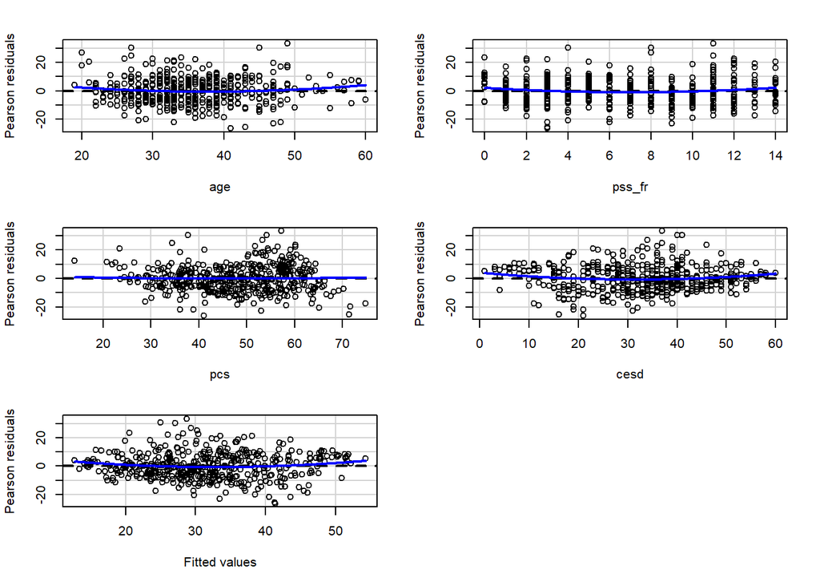

```
##            Test stat Pr(>|Test stat|)
## age           1.7429          0.08205 .
## pss_fr        2.1206          0.03451 *
## pcs           0.2997          0.76458
## cesd          2.2035          0.02807 *
## Tukey test    2.1051          0.03528 *
## ---
## Signif. codes:  0 '***' 0.001 '**' 0.01 '*' 0.05 '.' 0.1 ' ' 1
```

```r
library(car)
residualPlots(m2)
```

**Added Variable Plots**

Created from the model object `m2` using the `avPlots()` function from the `car` package. The code below highlights 2 outliers `id.n=2`.

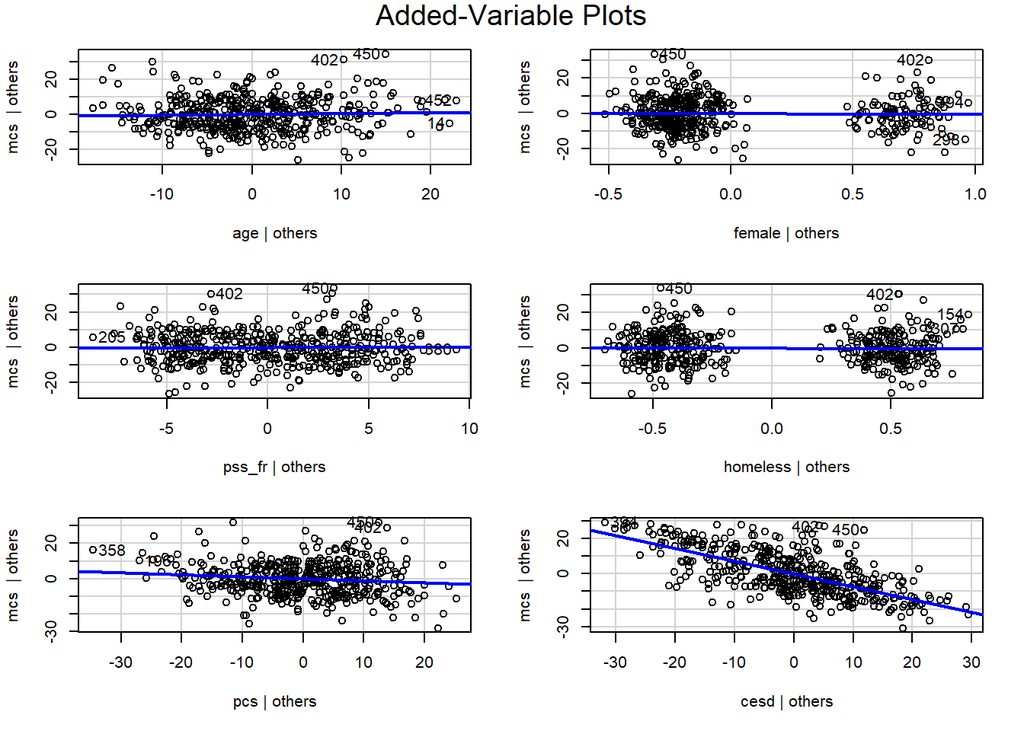

```r
avPlots(m2, id.n=2, id.cex=0.7)
```

**QQ Plot of Residuals**

Created from the model object `m2` using the `qqPlot()` function from the `car` package.

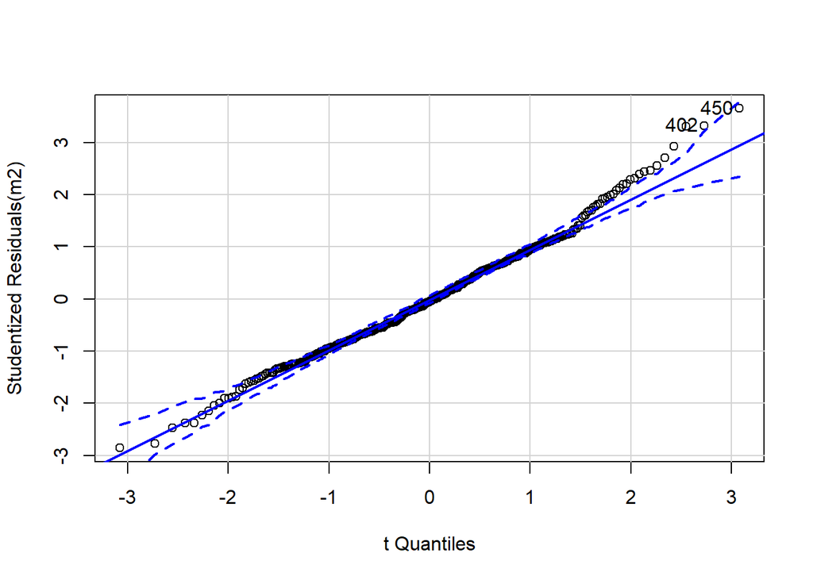

```
## [1] 402 450
```

```r
qqPlot(m2)
```

**Diagnostic Plots**

We can use other functions to look at various diagnostics and associated plots - the functions used below are all from the `car` package.

**Bonferroni Test for Outliers**

```r
#run Bonferroni test for outliers
outlierTest(m2)
```

```
## No Studentized residuals with Bonferonni p < 0.05
## Largest |rstudent|:
##     rstudent unadjusted p-value Bonferonni p
## 450 3.650316         0.00029302      0.13274
```

**Influence Index Plot**

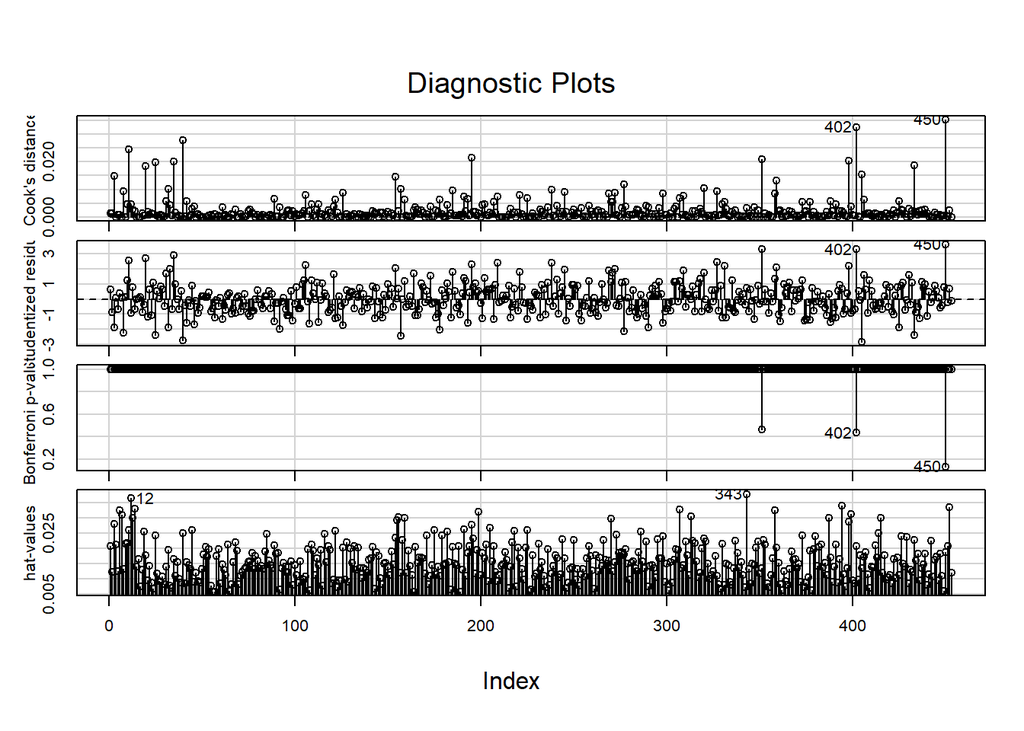

```r
#identify highly influential points
influenceIndexPlot(m2, id.n=3)
```

**Regression Influence Plot**

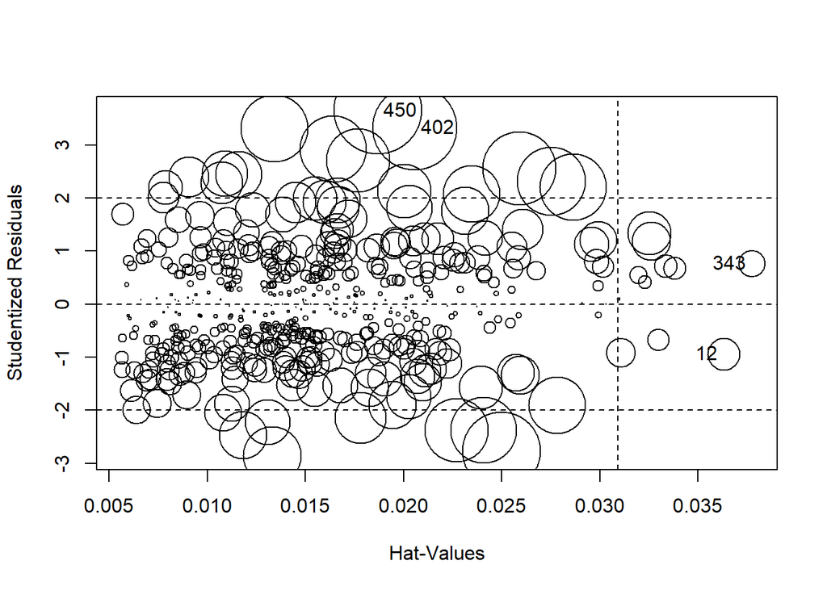

```
##        StudRes        Hat       CookD
## 12  -0.9379604 0.03629460 0.004734627
## 343  0.7654042 0.03774692 0.003286089
## 402  3.3240599 0.02057491 0.032428695
## 450  3.6503158 0.01868442 0.035269176
```

```r
#make influence plot
influencePlot(m2, id.n=3)
```

**Score Test for Non-Constant Error Variance - Test for Heteroskedasticity**

```r
#test for heteroskedasticity
ncvTest(m2)
```

```
## Non-constant Variance Score Test
## Variance formula: ~ fitted.values
## Chisquare = 3.973897, Df = 1, p = 0.046211
```

**Variance Inflation Factors (VIFs)**

```r
# get variance inflation factors for variables in model
vif(m2)
```

```
##      age   female   pss_fr homeless      pcs     cesd
## 1.076652 1.071447 1.082006 1.060145 1.179124 1.161041
```

### Logistic regression examples and exercises

We didn’t work a full example in class with R code, however, here is some example code for you to use to work out the homework exercises below.

#### Logistic regression model example

Run logistic regression model (and save results) for predicting CESD =>16 which predicts risk for clinical depression by `pcs`, the physical components score from the SF-36.

#### Table of Frequencies of CESD <16 and => 16

```r
# compute indicator for cesd => 16, add to h1
h1 <- h1 %>%
  mutate(cesd_gte16 = (cesd >= 16))

# check frequencies of cesd_gte16
table(h1$cesd_gte16)
```

```
##
## FALSE  TRUE
##    46   407
```

#### Logistic regression model

```r
# run logistic regression using glm()
m1 <- glm(cesd_gte16 ~ pcs, data=h1,
          family=binomial)

# look at the model results - minimal information
m1
```

```
##
## Call:  glm(formula = cesd_gte16 ~ pcs, family = binomial, data = h1)
##
## Coefficients:
## (Intercept)          pcs
##     5.39494     -0.06332
##
## Degrees of Freedom: 452 Total (i.e. Null);  451 Residual
## Null Deviance:       297.6
## Residual Deviance: 281.6     AIC: 285.6
```

#### Summary of logistic regression model

```r
# summary of the model results - more detailed with p-values
summary(m1)
```

```
##
## Call:
## glm(formula = cesd_gte16 ~ pcs, family = binomial, data = h1)
##
## Deviance Residuals:
##     Min       1Q   Median       3Q      Max
## -2.5948   0.2950   0.3973   0.5241   0.9135
##
## Coefficients:
##             Estimate Std. Error z value Pr(>|z|)
## (Intercept)  5.39494    0.91603   5.889 3.87e-09 ***
## pcs         -0.06332    0.01696  -3.734 0.000188 ***
## ---
## Signif. codes:  0 '***' 0.001 '**' 0.01 '*' 0.05 '.' 0.1 ' ' 1
##
## (Dispersion parameter for binomial family taken to be 1)
##
##     Null deviance: 297.59  on 452  degrees of freedom
## Residual deviance: 281.64  on 451  degrees of freedom
## AIC: 285.64
##
## Number of Fisher Scoring iterations: 5
```

**Remember** R outputs the RAW “beta” coefficients.

```r
# coefficients of the model - these are the
# RAW Betas
coef(m1)
```

```
## (Intercept)         pcs
##  5.39493600 -0.06332115
```

**Convert** the coefficients to odds ratios by taking the exponent of the coefficients.

```r
# take the exp to get the odds ratios
exp(coef(m1))
```

```
## (Intercept)         pcs
##  220.288049    0.938642
```

So, the odds ratio of `pcs` for predicting CESD => 16 is 0.9386. This means for every 1 point increase in PCS scores (improved physical quality of life) the odds of having a higher CESD score (=>16) is 0.9386. Or, conversely, for every one point lower someone scores on their PCS, the odds of scoring at or above 16 on the CESD is (1/0.9386 =) 1.065.

#### Logistic regression - save model predictions

```r
# look at the predicted probabilities
# review the help for predict.glm
m1.predict <- predict(m1, newdata=h1,
                      type="response")
```

#### Plot of Predicted Probabilities for CESD => 16 by PCS

Look at the plot below. What `pcs` value is the best for predicting between CESD scores above and below 16? Is there one? Do you think `pcs` is a good predictor for `cesd_gte16`?

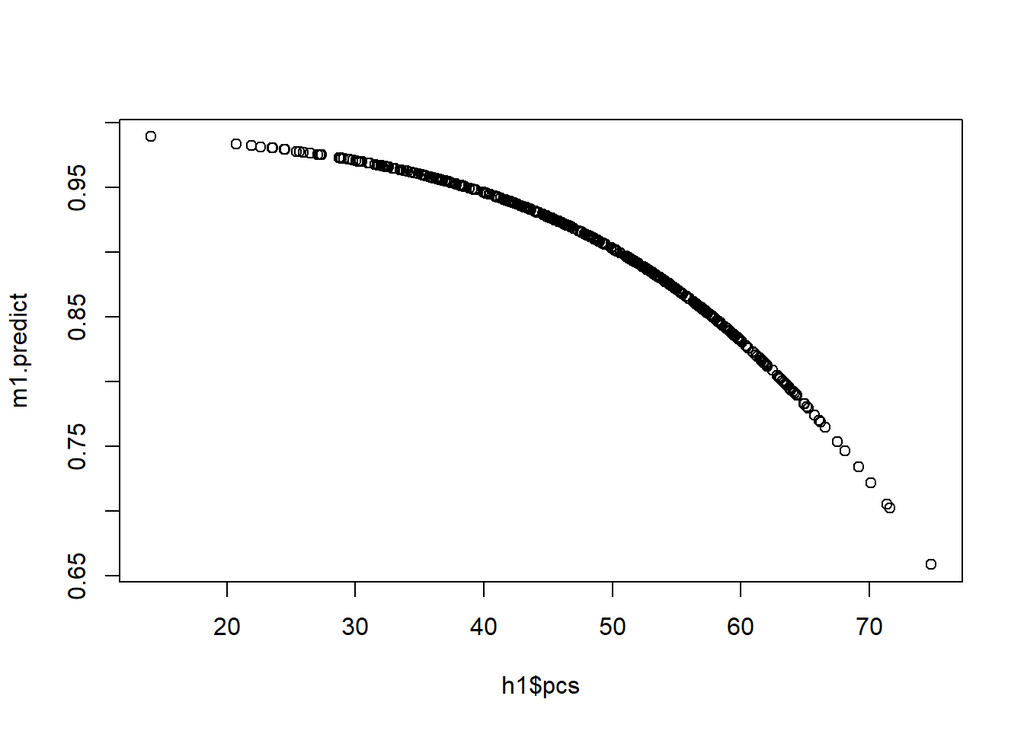

```r
# plot the continuous predictor pcs
# for the predicted probabilities for CESD => 16
plot(h1$pcs, m1.predict)
```

As the plot above and the table and scatterplot below shows, for the highest PCS value of 74.8, the probability of someone having a high CESD value is only 0.659. So, we need a different “cutpoint” to have any ability to predict individuals with lower CESD scores - at least for this PCS predictor, which doesn’t seem like a very good predictor.

```r
# add predicted values to h1 dataset
# then arrange (sort) by pcs and view
# highest values using tail
h1 %>%
  mutate(pcspredict = m1.predict) %>%
  arrange(pcs) %>%
  tail()
```

```
## # A tibble: 6 x 9
##     age female    pss_fr homeless    pcs   mcs  cesd cesd_gte16 pcspredict
##   <dbl> <dbl+lbl>  <dbl> <dbl+lbl> <dbl> <dbl> <dbl> <lgl>           <dbl>
## 1    30 0              7 1          68.1 17.4     36 TRUE            0.747
## 2    29 1              4 1          69.2  9.73    47 TRUE            0.734
## 3    25 0              5 0          70.1 14.5     43 TRUE            0.722
## 4    43 0              3 1          71.4 15.9     16 TRUE            0.706
## 5    29 0              6 1          71.6 18.7     19 TRUE            0.703
## 6    26 0             13 0          74.8  6.76    39 TRUE            0.659
```

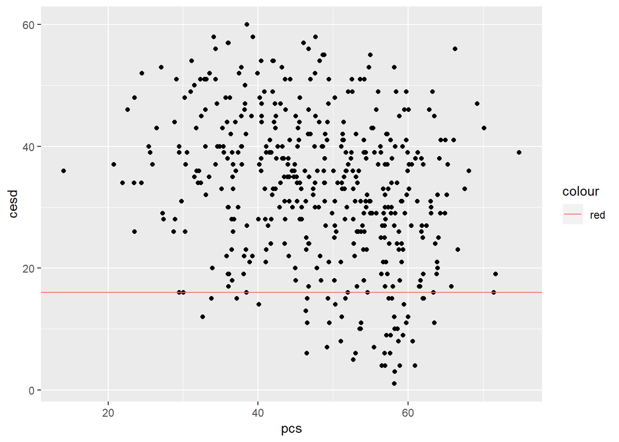

```r
ggplot(h1, aes(pcs, cesd)) +
  geom_point() +
  geom_hline(aes(yintercept = 16, color = "red"))
```

Anyway, let’s try some prediction thresholds above 0.5. We’ll start at 0.70 and try a few above that to see if there is a value that provides a reasonable tradeoff between false positives (people predicted to be depressed who aren’t) and false negatives (people who predicted to NOT be depressed but who really are). Remember, this model is already skewed towards predicting that everyone is depressed.

#### Try different decision thresholds (0.70, 0.75, 0.80, 0.85)

Try different thresholds for deciding between the 2 outcomes (CESD < 16) versus (CESD =>16). These can vary from close to 0 to close to 1. The code below explores 0.70, 0.75, 0.80, 0.85. Try different ones and compare the confusion matrices to see how the tradeoffs change the false positives and false negatives.

FYI - a good online calculator to explore is at http://statpages.info/ctab2x2.html.

**NOTE** For the example code below, I’m looking at predicting homeless for a probability > 0.70 and higher. You may need to adjust this in your problems below. Typically this is set to around 0.5.

```r
# Look at the tradeoffs for threshold 0.75

# confusion matrix
table(h1$cesd_gte16, m1.predict > 0.70)
```

```
##
##         FALSE TRUE
##   FALSE     0   46
##   TRUE      1  406
```

```r
# rearrange slightly
# compare to this online calculator
# http://statpages.info/ctab2x2.html

t1 <- table(m1.predict > 0.70, h1$cesd_gte16)
t1
```

```
##
##         FALSE TRUE
##   FALSE     0    1
##   TRUE     46  406
```

```r
tpr <- t1[2,2]/(t1[2,2]+t1[1,2])
tpr #senstivity
```

```
## [1] 0.997543
```

```r
tnr <- t1[1,1]/(t1[1,1]+t1[2,1])
tnr #specificity
```

```
## [1] 0
```

```r
# we can use these data to compile
#     TRUE Positives
#     FALSE Positives
#     TRUE Negatives
#     FALSE Negatives

# see what happens if we try other
# threshold values
t1 <- table(m1.predict > 0.75, h1$cesd_gte16)
t1
```

```
##
##         FALSE TRUE
##   FALSE     0    6
##   TRUE     46  401
```

```r
tpr <- t1[2,2]/(t1[2,2]+t1[1,2])
tpr #senstivity
```

```
## [1] 0.985258
```

```r
tnr <- t1[1,1]/(t1[1,1]+t1[2,1])
tnr #specificity
```

```
## [1] 0
```

```r
t1 <- table(m1.predict > 0.80, h1$cesd_gte16)
t1
```

```
##
##         FALSE TRUE
##   FALSE     1   26
##   TRUE     45  381
```

```r
tpr <- t1[2,2]/(t1[2,2]+t1[1,2])
tpr #senstivity
```

```
## [1] 0.9361179
```

```r
tnr <- t1[1,1]/(t1[1,1]+t1[2,1])
tnr #specificity
```

```
## [1] 0.02173913
```

```r
t1 <- table(m1.predict > 0.85, h1$cesd_gte16)
t1
```

```
##
##         FALSE TRUE
##   FALSE    18   76
##   TRUE     28  331
```

```r
tpr <- t1[2,2]/(t1[2,2]+t1[1,2])
tpr #senstivity
```

```
## [1] 0.8132678
```

```r
tnr <- t1[1,1]/(t1[1,1]+t1[2,1])
tnr #specificity
```

```
## [1] 0.3913043
```

So, we have to set a pretty high threshold of 0.85 before we’re predicting many subjects as not depressed, albeit at the expense of more false negatives.

#### Option to use `gmodels` package and the `gmodels::CrossTable()` function to get your tables

```r
# another way to look at cross tables
library(gmodels)
CrossTable(h1$homeless, m1.predict > 0.80)
```

```
##
##
##    Cell Contents
## |-------------------------|
## |                       N |
## | Chi-square contribution |
## |           N / Row Total |
## |           N / Col Total |
## |         N / Table Total |
## |-------------------------|
##
##
## Total Observations in Table:  453
##
##
##              | m1.predict > 0.8
##  h1$homeless |     FALSE |      TRUE | Row Total |
## -------------|-----------|-----------|-----------|
##            0 |        14 |       230 |       244 |
##              |     0.020 |     0.001 |           |
##              |     0.057 |     0.943 |     0.539 |
##              |     0.519 |     0.540 |           |
##              |     0.031 |     0.508 |           |
## -------------|-----------|-----------|-----------|
##            1 |        13 |       196 |       209 |
##              |     0.024 |     0.002 |           |
##              |     0.062 |     0.938 |     0.461 |
##              |     0.481 |     0.460 |           |
##              |     0.029 |     0.433 |           |
## -------------|-----------|-----------|-----------|
## Column Total |        27 |       426 |       453 |
##              |     0.060 |     0.940 |           |
## -------------|-----------|-----------|-----------|
##
##
```

#### Making ROC Curves and computing AUC

The code below will generate a ROC (receiver operating characteristic) curve and compute the AUC (area under the curve), which is also called the “C-statistic”. Ideally we’d like the AUC > 0.7, and values of 0.8 and 0.9 are even better. An AUC of 1.0 indicates that the model is perfect - there are no false positives or false negatives, which never happens. *… well if it does happen, I’d be suspicious of the model…*

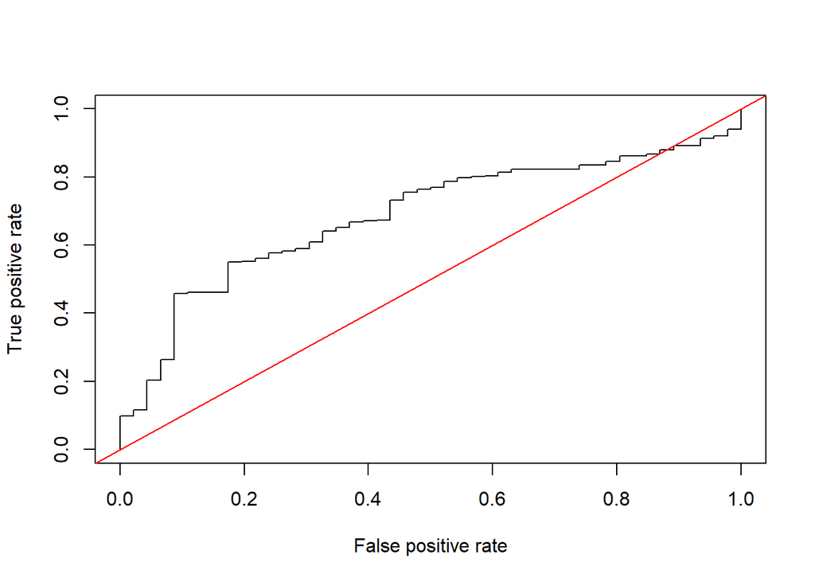

```r
# another way to look at tradeoffs
# of picking different thresholds
# make an ROC curve

library(ROCR)
p <- predict(m1, newdata=h1,
             type="response")
pr <- prediction(p, as.numeric(h1$cesd_gte16))
prf <- performance(pr, measure = "tpr", x.measure = "fpr")
plot(prf)
abline(a=0, b=1, col="red")
```

```r
# the area under this curve compared
# to the y=x reference line
# tells you how well the model is predicting
# and AUC of 0.5 is a bad model - no better
# than flipping a coin
# AUC of 0.6-0.7 is still not very good
# AUC of 0.7-0.8 is pretty good
# AUC of 0.8-0.9 is good
# AUC 0.9-1.0 is great

auc <- performance(pr, measure = "auc")
auc <- auc@y.values[[1]]
auc
```

```
## [1] 0.6855571
```

The auc here is 0.6855571 which is not very good. The PCS is not a good predictor of CESD => 16 depression risk.

### Homework 6 problems for logistic regression

7. [Model 3] Run a logistic regression (`glm()`) to predict `homeless` as a function of `mcs` scores. Show a `summary(model)` of the final fitted model and explain the coefficients. [**REMEMBER** to compute the Odds Ratios after you get the raw coefficient (betas), using `exp(coef(model))`)].

### Problem 7: ANSWER KEY

```r
# run logistic regression using glm()
m3 <- glm(homeless ~ mcs, data=h1,
          family=binomial)

# look at the model summary
summary(m3)
```

```
##
## Call:
## glm(formula = homeless ~ mcs, family = binomial, data = h1)
##
## Deviance Residuals:
##    Min      1Q  Median      3Q     Max
## -1.225  -1.125  -1.011   1.223   1.381
##
## Coefficients:
##              Estimate Std. Error z value Pr(>|z|)
## (Intercept)  0.184611   0.251844   0.733    0.464
## mcs         -0.010742   0.007408  -1.450    0.147
##
## (Dispersion parameter for binomial family taken to be 1)
##
##     Null deviance: 625.28  on 452  degrees of freedom
## Residual deviance: 623.17  on 451  degrees of freedom
## AIC: 627.17
##
## Number of Fisher Scoring iterations: 4
```

Get odds ratios using the `exp()` function of `coef()`.

```r
# take the exp to get the odds ratios
exp(coef(m3))
```

```
## (Intercept)         mcs
##   1.2027505   0.9893153
```

For every 1 point increase in mcs scores the odds of being homeless go down, odds ratio was 0.989. However, `mcs` was not a statistically significant predictor of `homeless` (p = 0.147).

8. Make a plot showing the probability curve - put the `mcs` values on the X-axis and the probability of `homeless` on the Y-axis (like `m1.predict` above). Based on this plot, do you think the `mcs` is a good predictor of homelessness? [**FYI** This plot is also called an “effect plot” is you’re using `Rcmdr` to do these analyses.]

### Problem 8: ANSWER KEY

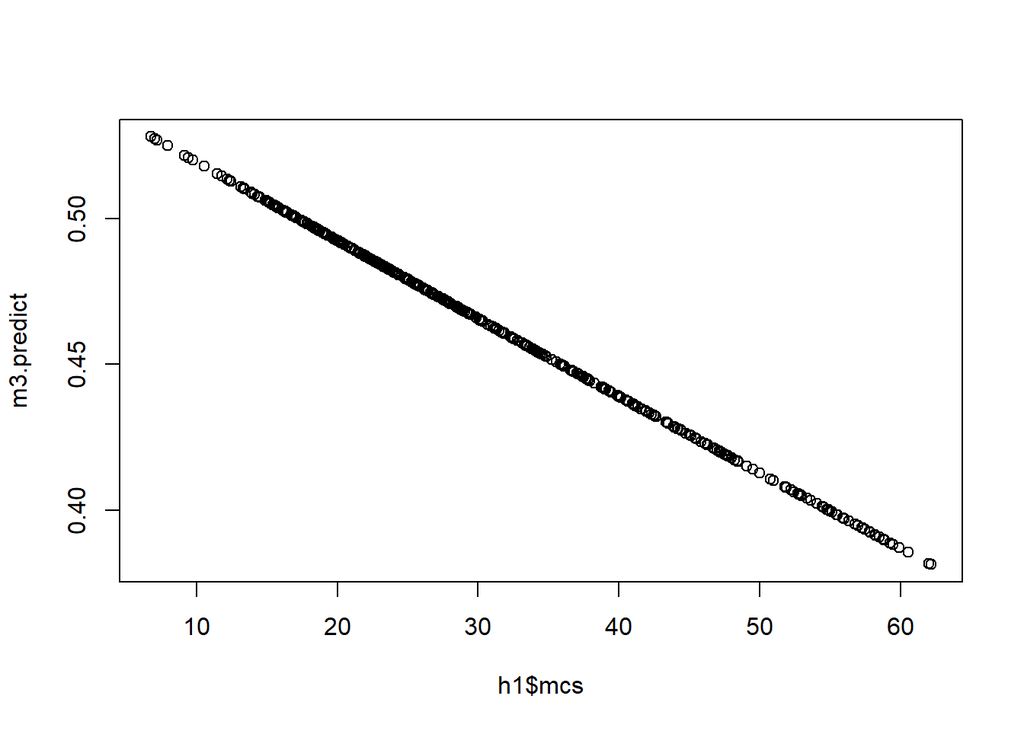

```r
# look at the predicted probabilities
# review the help for predict.glm
m3.predict <- predict(m3, newdata=h1,
                      type="response")

# plot the continuous predictor mcs
# for the predicted probabilities for homeless
plot(h1$mcs, m3.predict)
```

The probability of being homeless does go down as the `mcs` scores go up (better mental health) which seems logical. However, it looks like it takes really low scores on the `mcs` to predict a probability of being homeless > 0.5.

It does not seem that `mcs` is a very good predictor of `homeless`.

9. Use the `predict()` function like the code example above to predict `homeless` and compare it back to the original data (see the code above for the tables using different thresholds for looking at correct predictions, false positives and false negatives). For this problem, go ahead and use a cutoff probability of 0.5.

### Problem 9: ANSWER KEY

```r
# confusion matrix
# compare to this online calculator
# http://statpages.info/ctab2x2.html

t1 <- table(m3.predict > 0.50, h1$homeless)
t1
```

```
##
##           0   1
##   FALSE 215 187
##   TRUE   29  22
```

```r
tpr <- t1[2,2]/(t1[2,2]+t1[1,2])
tpr #senstivity
```

```
## [1] 0.1052632
```

```r
tnr <- t1[1,1]/(t1[1,1]+t1[2,1])
tnr #specificity
```

```
## [1] 0.8811475
```

```
+ How well did the model correctly predict `homeless`? (make the "confusion matrix" and look at the true positives and true negatives versus the false positives and false negatives).
+ **EXTRA CREDIT** What threshold does the best job trading off between false positives and false negatives?
```

It looks like using a threshold of 0.5, `mcs` only correctly predicted 22 of the 209 homeless people (10.5% correct) and correctly predicted 215 of the 244 non-homeless (88.1% correct).

### EXTRA CREDIT

Try different thresholds from 0.1 to 0.9.

```r
table(m3.predict > 0.10, h1$homeless)
```

```
##
##          0   1
##   TRUE 244 209
```

```r
table(m3.predict > 0.20, h1$homeless)
```

```
##
##          0   1
##   TRUE 244 209
```

```r
table(m3.predict > 0.30, h1$homeless)
```

```
##
##          0   1
##   TRUE 244 209
```

```r
table(m3.predict > 0.40, h1$homeless)
```

```
##
##           0   1
##   FALSE  17  11
##   TRUE  227 198
```

```r
table(m3.predict > 0.50, h1$homeless)
```

```
##
##           0   1
##   FALSE 215 187
##   TRUE   29  22
```

```r
table(m3.predict > 0.60, h1$homeless)
```

```
##
##           0   1
##   FALSE 244 209
```

```r
table(m3.predict > 0.70, h1$homeless)
```

```
##
##           0   1
##   FALSE 244 209
```

```r
table(m3.predict > 0.80, h1$homeless)
```

```
##
##           0   1
##   FALSE 244 209
```

```r
table(m3.predict > 0.90, h1$homeless)
```

```
##
##           0   1
##   FALSE 244 209
```

It looks like somewhere between 0.4 and 0.5 might be best - try a few more…

```r
table(m3.predict > 0.41, h1$homeless)
```

```
##
##           0   1
##   FALSE  29  19
##   TRUE  215 190
```

```r
table(m3.predict > 0.42, h1$homeless)
```

```
##
##           0   1
##   FALSE  42  26
##   TRUE  202 183
```

```r
table(m3.predict > 0.43, h1$homeless)
```

```
##
##           0   1
##   FALSE  58  37
##   TRUE  186 172
```

```r
table(m3.predict > 0.44, h1$homeless)
```

```
##
##           0   1
##   FALSE  76  50
##   TRUE  168 159
```

```r
table(m3.predict > 0.45, h1$homeless)
```

```
##
##           0   1
##   FALSE 100  58
##   TRUE  144 151
```

```r
table(m3.predict > 0.46, h1$homeless)
```

```
##
##           0   1
##   FALSE 115  75
##   TRUE  129 134
```

```r
table(m3.predict > 0.47, h1$homeless)
```

```
##
##           0   1
##   FALSE 135 100
##   TRUE  109 109
```

```r
table(m3.predict > 0.48, h1$homeless)
```

```
##
##           0   1
##   FALSE 161 135
##   TRUE   83  74
```

```r
table(m3.predict > 0.49, h1$homeless)
```

```
##
##           0   1
##   FALSE 188 164
##   TRUE   56  45
```

Looks like there is a tradeoff that works well between 0.47 and 0.48…

10. Make an ROC curve plot and compute the AUC and explain if this is a good model for predicting `homeless` or not.

### Problem 10: ANSWER KEY

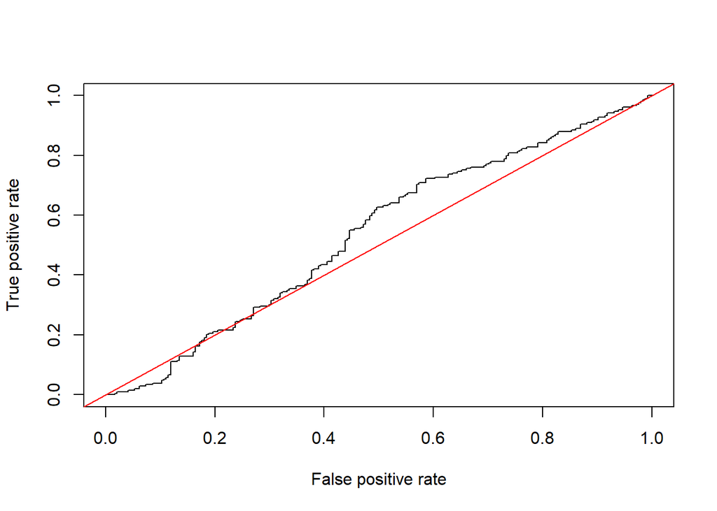

```r
# another way to look at tradeoffs
# of picking different thresholds
# make an ROC curve

library(ROCR)
p <- predict(m3, newdata=h1,
             type="response")
pr <- prediction(p, as.numeric(h1$homeless))
prf <- performance(pr, measure = "tpr", x.measure = "fpr")
plot(prf)
abline(a=0, b=1, col="red")
```

```r
# the area under this curve compared
# to the y=x reference line
# tells you how well the model is predicting
# and AUC of 0.5 is a bad model - no better
# than flipping a coin
# AUC of 0.6-0.7 is still not very good
# AUC of 0.7-0.8 is pretty good
# AUC of 0.8-0.9 is good
# AUC 0.9-1.0 is great

auc <- performance(pr, measure = "auc")
auc <- auc@y.values[[1]]
auc
```

```
## [1] 0.5364342
```

The AUC is only 0.536 which is really close to 0.5 so basically flipping a coin. The `mcs` is not a good predictor for homelessness.

**Use R markdown to complete your homework and show all of your code and output in your final report - Turn in a PDF of your report to Canvas (show your code - use `echo=TRUE` for your R code chunks).**